# Data Mining CART-RF-ANN Project

```python
import numpy as np
import pandas as pd
import matplotlib.pyplot as plt
import seaborn as sns
from sklearn import tree
from sklearn.tree import DecisionTreeClassifier
from sklearn.ensemble import RandomForestClassifier
from sklearn.neural_network import MLPClassifier
from sklearn.model_selection import train_test_split
from sklearn.metrics import roc_auc_score,roc_curve,classification_report,confusion_matrix
from sklearn.preprocessing import StandardScaler
from sklearn.model_selection import GridSearchCV
```

```python
import os
os.chdir('C:\\Users\\tmaji\\Downloads')
os.getcwd()
```

```
'C:\\Users\\tmaji\\Downloads'
```

```python
df=pd.read_csv('insurance_part2_data.csv')
df.head()
```

|  | Age | Agency_Code | Type | Claimed | Commision | Channel | Duration | Sales | Product Name | Destination |
| --- | --- | --- | --- | --- | --- | --- | --- | --- | --- | --- |
| 0 | 48 | C2B | Airlines | No | 0.70 | Online | 7 | 2.51 | Customised Plan | ASIA |
| 1 | 36 | EPX | Travel Agency | No | 0.00 | Online | 34 | 20.00 | Customised Plan | ASIA |
| 2 | 39 | CWT | Travel Agency | No | 5.94 | Online | 3 | 9.90 | Customised Plan | Americas |
| 3 | 36 | EPX | Travel Agency | No | 0.00 | Online | 4 | 26.00 | Cancellation Plan | ASIA |
| 4 | 33 | JZI | Airlines | No | 6.30 | Online | 53 | 18.00 | Bronze Plan | ASIA |

# 2.1 Read the data, do the necessary initial steps, and exploratory data analysis (Univariate, Bi-variate, and multivariate analysis).

```python
df.info()
```

```
<class 'pandas.core.frame.DataFrame'>
RangeIndex: 3000 entries, 0 to 2999
Data columns (total 10 columns):
 #   Column        Non-Null Count  Dtype
---  ------        --------------  -----
 0   Age           3000 non-null   int64
 1   Agency_Code   3000 non-null   object
 2   Type          3000 non-null   object
 3   Claimed       3000 non-null   object
 4   Commision     3000 non-null   float64
 5   Channel       3000 non-null   object
 6   Duration      3000 non-null   int64
 7   Sales         3000 non-null   float64
 8   Product Name  3000 non-null   object
 9   Destination   3000 non-null   object
dtypes: float64(2), int64(2), object(6)
memory usage: 234.5+ KB
```

```python
df.shape
```

```
(3000, 10)
```

```python
df.describe(include="all").T
```

|  | count | unique | top | freq | mean | std | min | 25% | 50% | 75% | max |
| --- | --- | --- | --- | --- | --- | --- | --- | --- | --- | --- | --- |
| Age | 3000.0 | NaN | NaN | NaN | 38.091 | 10.463518 | 8.0 | 32.0 | 36.0 | 42.0 | 84.0 |
| Agency_Code | 3000 | 4 | EPX | 1365 | NaN | NaN | NaN | NaN | NaN | NaN | NaN |
| Type | 3000 | 2 | Travel Agency | 1837 | NaN | NaN | NaN | NaN | NaN | NaN | NaN |
| Claimed | 3000 | 2 | No | 2076 | NaN | NaN | NaN | NaN | NaN | NaN | NaN |
| Commision | 3000.0 | NaN | NaN | NaN | 14.529203 | 25.481455 | 0.0 | 0.0 | 4.63 | 17.235 | 210.21 |
| Channel | 3000 | 2 | Online | 2954 | NaN | NaN | NaN | NaN | NaN | NaN | NaN |
| Duration | 3000.0 | NaN | NaN | NaN | 70.001333 | 134.053313 | -1.0 | 11.0 | 26.5 | 63.0 | 4580.0 |
| Sales | 3000.0 | NaN | NaN | NaN | 60.249913 | 70.733954 | 0.0 | 20.0 | 33.0 | 69.0 | 539.0 |
| Product Name | 3000 | 5 | Customised Plan | 1136 | NaN | NaN | NaN | NaN | NaN | NaN | NaN |
| Destination | 3000 | 3 | ASIA | 2465 | NaN | NaN | NaN | NaN | NaN | NaN | NaN |

# Checking Duplicates¶

```python
dups = df.duplicated()
print('Number of duplicate rows = %d' % (dups.sum()))
```

```
Number of duplicate rows = 139
```

# Removing Duplicates

```python
df.drop_duplicates(inplace=True)
```

```python
dups = df.duplicated()
print('Number of duplicate rows = %d' % (dups.sum()))
print(df.shape)
```

```
Number of duplicate rows = 0
(2861, 10)
```

# Checking Outliers

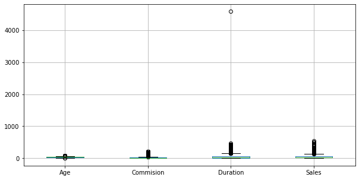

```python
#Univariate analysis
plt.figure(figsize=(10,5))
df[['Age','Commision', 'Duration', 'Sales']].boxplot()
```

# from the above graph we can conclude that the below varibles are with outliers:

Age,Commision,Duration, Sales

# Checking pairwise distribution of continous variables

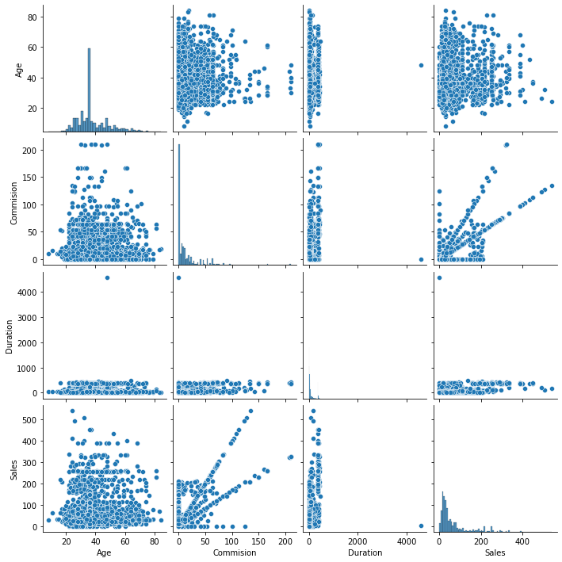

```python
#Mult variate analysis
sns.pairplot(df[['Age','Commision', 'Duration', 'Sales']])
```

# Checking for Correlation

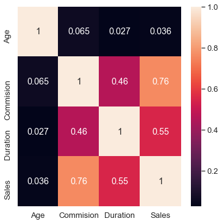

```python
plt.figure(figsize=(6,6))
sns.set(font_scale=1.2)
sns.heatmap(df[['Age','Commision', 'Duration', 'Sales']].corr(), annot=True)
```

# Converting all objects to categorical code

```python
for feature in df.columns:
    if df[feature].dtype == 'object':
        print('\n')
        print('feature:',feature)
        print(pd.Categorical(df[feature].unique()))
        print(pd.Categorical(df[feature].unique()).codes)
        df[feature] = pd.Categorical(df[feature]).codes
```

```
feature: Agency_Code
['C2B', 'EPX', 'CWT', 'JZI']
Categories (4, object): ['C2B', 'CWT', 'EPX', 'JZI']
[0 2 1 3]


feature: Type
['Airlines', 'Travel Agency']
Categories (2, object): ['Airlines', 'Travel Agency']
[0 1]


feature: Claimed
['No', 'Yes']
Categories (2, object): ['No', 'Yes']
[0 1]


feature: Channel
['Online', 'Offline']
Categories (2, object): ['Offline', 'Online']
[1 0]


feature: Product Name
['Customised Plan', 'Cancellation Plan', 'Bronze Plan', 'Silver Plan', 'Gold Plan']
Categories (5, object): ['Bronze Plan', 'Cancellation Plan', 'Customised Plan', 'Gold Plan', 'Silver Plan']
[2 1 0 4 3]


feature: Destination
['ASIA', 'Americas', 'EUROPE']
Categories (3, object): ['ASIA', 'Americas', 'EUROPE']
[0 1 2]
```

```python
df.info()
```

```
<class 'pandas.core.frame.DataFrame'>
Int64Index: 2861 entries, 0 to 2999
Data columns (total 10 columns):
 #   Column        Non-Null Count  Dtype
---  ------        --------------  -----
 0   Age           2861 non-null   int64
 1   Agency_Code   2861 non-null   int8
 2   Type          2861 non-null   int8
 3   Claimed       2861 non-null   int8
 4   Commision     2861 non-null   float64
 5   Channel       2861 non-null   int8
 6   Duration      2861 non-null   int64
 7   Sales         2861 non-null   float64
 8   Product Name  2861 non-null   int8
 9   Destination   2861 non-null   int8
dtypes: float64(2), int64(2), int8(6)
memory usage: 128.5 KB
```

```python
df.head()
```

|  | Age | Agency_Code | Type | Claimed | Commision | Channel | Duration | Sales | Product Name | Destination |
| --- | --- | --- | --- | --- | --- | --- | --- | --- | --- | --- |
| 0 | 48 | 0 | 0 | 0 | 0.70 | 1 | 7 | 2.51 | 2 | 0 |
| 1 | 36 | 2 | 1 | 0 | 0.00 | 1 | 34 | 20.00 | 2 | 0 |
| 2 | 39 | 1 | 1 | 0 | 5.94 | 1 | 3 | 9.90 | 2 | 1 |
| 3 | 36 | 2 | 1 | 0 | 0.00 | 1 | 4 | 26.00 | 1 | 0 |
| 4 | 33 | 3 | 0 | 0 | 6.30 | 1 | 53 | 18.00 | 0 | 0 |

```python
#1s and 0s count
df.Claimed.value_counts(normalize=True)
```

```
0    0.680531
1    0.319469
Name: Claimed, dtype: float64
```

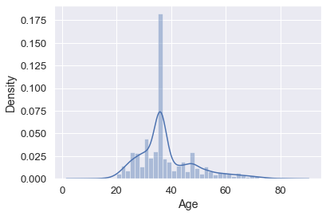

```python
#distplot
sns.distplot(df['Age'])
```

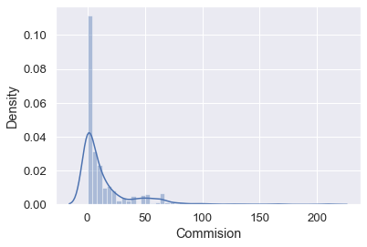

```python
#distplot
sns.distplot(df['Commision'])
```

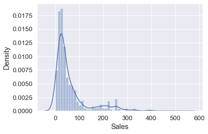

```python
#distplot
sns.distplot(df['Sales'])
```

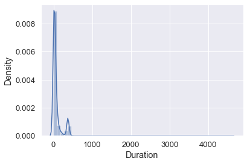

```python
#distplot
sns.distplot(df['Duration'])
```

# from the above graph we can conclude that:below vaibles are right skewed

Age, Duration, Sales, Commision

# 2.2 Data Split: Split the data into test and train, build classification model CART, Random Forest, Artificial Neural Network

Extracting the target column into separate vectors for training set and test set

```python
df1=df.copy()
df1.head()
```

|  | Age | Agency_Code | Type | Claimed | Commision | Channel | Duration | Sales | Product Name | Destination |
| --- | --- | --- | --- | --- | --- | --- | --- | --- | --- | --- |
| 0 | 48 | 0 | 0 | 0 | 0.70 | 1 | 7 | 2.51 | 2 | 0 |
| 1 | 36 | 2 | 1 | 0 | 0.00 | 1 | 34 | 20.00 | 2 | 0 |
| 2 | 39 | 1 | 1 | 0 | 5.94 | 1 | 3 | 9.90 | 2 | 1 |
| 3 | 36 | 2 | 1 | 0 | 0.00 | 1 | 4 | 26.00 | 1 | 0 |
| 4 | 33 | 3 | 0 | 0 | 6.30 | 1 | 53 | 18.00 | 0 | 0 |

```python
X = df1.drop("Claimed", axis=1)
y = df1.pop("Claimed")

X.head()
```

|  | Age | Agency_Code | Type | Commision | Channel | Duration | Sales | Product Name | Destination |
| --- | --- | --- | --- | --- | --- | --- | --- | --- | --- |
| 0 | 48 | 0 | 0 | 0.70 | 1 | 7 | 2.51 | 2 | 0 |
| 1 | 36 | 2 | 1 | 0.00 | 1 | 34 | 20.00 | 2 | 0 |
| 2 | 39 | 1 | 1 | 5.94 | 1 | 3 | 9.90 | 2 | 1 |
| 3 | 36 | 2 | 1 | 0.00 | 1 | 4 | 26.00 | 1 | 0 |
| 4 | 33 | 3 | 0 | 6.30 | 1 | 53 | 18.00 | 0 | 0 |

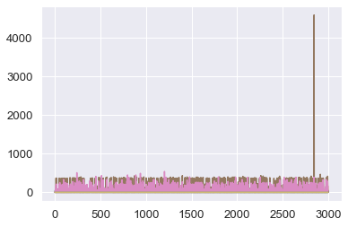

```python
# prior to scaling
plt.plot(X)
plt.show()
```

```python
# Scaling the attributes.

from scipy.stats import zscore
X_scaled=X.apply(zscore)
X_scaled.head()
```

|  | Age | Agency_Code | Type | Commision | Channel | Duration | Sales | Product Name | Destination |
| --- | --- | --- | --- | --- | --- | --- | --- | --- | --- |
| 0 | 0.917540 | -1.276081 | -1.217993 | -0.556921 | 0.127832 | -0.478989 | -0.829950 | 0.260997 | -0.446648 |
| 1 | -0.206451 | 0.716750 | 0.821023 | -0.584029 | 0.127832 | -0.280392 | -0.584949 | 0.260997 | -0.446648 |
| 2 | 0.074546 | -0.279665 | 0.821023 | -0.353996 | 0.127832 | -0.508411 | -0.726430 | 0.260997 | 1.259439 |
| 3 | -0.206451 | 0.716750 | 0.821023 | -0.584029 | 0.127832 | -0.501056 | -0.500900 | -0.521721 | -0.446648 |
| 4 | -0.487449 | 1.713166 | -1.217993 | -0.340055 | 0.127832 | -0.140638 | -0.612965 | -1.304440 | -0.446648 |

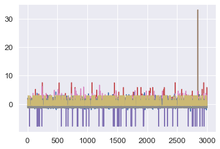

```python
# prior to scaling
plt.plot(X_scaled)
plt.show()
```

# Spitting data into train and test set

```python
from sklearn.model_selection import train_test_split

X_train, X_test, train_labels, test_labels = train_test_split(X_scaled, y, test_size=.30, random_state=5)
```

# Checking the dimensions of the training and test data

```python
print('X_train',X_train.shape)
print('X_test',X_test.shape)
print('train_labels',train_labels.shape)
print('test_labels',test_labels.shape)
```

```
X_train (2002, 9)
X_test (859, 9)
train_labels (2002,)
test_labels (859,)
```

# Model 1 # Building decision tree classifier

```python
param_grid_dtcl = {
    'criterion': ['gini'],
    'max_depth': [10,20,30,50],
    'min_samples_leaf': [50,100,150],
    'min_samples_split': [150,300,450],
}

dtcl = DecisionTreeClassifier(random_state=1)

grid_search_dtcl = GridSearchCV(estimator = dtcl, param_grid = param_grid_dtcl, cv = 10)
```

```python
grid_search_dtcl.fit(X_train, train_labels)
print(grid_search_dtcl.best_params_)
best_grid_dtcl = grid_search_dtcl.best_estimator_
best_grid_dtcl
```

```
{'criterion': 'gini', 'max_depth': 10, 'min_samples_leaf': 50, 'min_samples_split': 300}
```

```
DecisionTreeClassifier(max_depth=10, min_samples_leaf=50, min_samples_split=300,
                       random_state=1)
```

```python
param_grid_dtcl = {
    'criterion': ['gini'],
    'max_depth': [3, 5, 7, 10,12],
    'min_samples_leaf': [20,30,40,50,60],
    'min_samples_split': [150,300,450],
}

dtcl = DecisionTreeClassifier(random_state=1)

grid_search_dtcl = GridSearchCV(estimator = dtcl, param_grid = param_grid_dtcl, cv = 10)
```

```python
grid_search_dtcl.fit(X_train, train_labels)
print(grid_search_dtcl.best_params_)
best_grid_dtcl = grid_search_dtcl.best_estimator_
best_grid_dtcl
```

```
{'criterion': 'gini', 'max_depth': 5, 'min_samples_leaf': 50, 'min_samples_split': 300}
```

```
DecisionTreeClassifier(max_depth=5, min_samples_leaf=50, min_samples_split=300,
                       random_state=1)
```

```python
param_grid_dtcl = {
    'criterion': ['gini'],
    'max_depth': [3.5,4.0,4.5, 5.0,5.5],
    'min_samples_leaf': [40, 42, 44,46,48,50,52,54],
    'min_samples_split': [250, 270, 280, 290, 300,310],
}

dtcl = DecisionTreeClassifier(random_state=1)

grid_search_dtcl = GridSearchCV(estimator = dtcl, param_grid = param_grid_dtcl, cv = 10)
```

```python
grid_search_dtcl.fit(X_train, train_labels)
print(grid_search_dtcl.best_params_)
best_grid_dtcl = grid_search_dtcl.best_estimator_
best_grid_dtcl
```

```
{'criterion': 'gini', 'max_depth': 5.0, 'min_samples_leaf': 42, 'min_samples_split': 250}
```

```
DecisionTreeClassifier(max_depth=5.0, min_samples_leaf=42,
                       min_samples_split=250, random_state=1)
```

```python
param_grid_dtcl = {
    'criterion': ['gini'],
    'max_depth': [4.85, 4.90,4.95, 5.0,5.05,5.10,5.15],
    'min_samples_leaf': [40, 41, 42, 43, 44],
    'min_samples_split': [150, 175, 200, 210, 220, 230, 240, 250, 260, 270],
}

dtcl = DecisionTreeClassifier(random_state=1)

grid_search_dtcl = GridSearchCV(estimator = dtcl, param_grid = param_grid_dtcl, cv = 10)
```

```python
grid_search_dtcl.fit(X_train, train_labels)
print(grid_search_dtcl.best_params_)
best_grid_dtcl = grid_search_dtcl.best_estimator_
best_grid_dtcl
```

```
{'criterion': 'gini', 'max_depth': 5.0, 'min_samples_leaf': 42, 'min_samples_split': 230}
```

```
DecisionTreeClassifier(max_depth=5.0, min_samples_leaf=42,
                       min_samples_split=230, random_state=1)
```

# Generating Tree

```python
train_char_label = ['no', 'yes']
tree_regularized = open('tree_regularized.dot','w')
dot_data = tree.export_graphviz(best_grid_dtcl, out_file= tree_regularized ,
                                feature_names = list(X_train),
                                class_names = list(train_char_label))

tree_regularized.close()
dot_data
```

# Variable Importance - DTCL

```python
print (pd.DataFrame(best_grid_dtcl.feature_importances_, columns = ["Imp"],
                    index = X_train.columns).sort_values('Imp',ascending=False))
```

```
                   Imp
Agency_Code   0.608787
Sales         0.206681
Product Name  0.085441
Duration      0.059490
Age           0.028028
Commision     0.011574
Type          0.000000
Channel       0.000000
Destination   0.000000
```

# Predicting on Training and Test dataset

```python
ytrain_predict_dtcl = best_grid_dtcl.predict(X_train)
ytest_predict_dtcl = best_grid_dtcl.predict(X_test)
```

# Getting the Predicted Classes and Probs

```python
ytest_predict_dtcl
ytest_predict_prob_dtcl=best_grid_dtcl.predict_proba(X_test)
ytest_predict_prob_dtcl
pd.DataFrame(ytest_predict_prob_dtcl).head()
```

|  | 0 | 1 |
| --- | --- | --- |
| 0 | 0.343066 | 0.656934 |
| 1 | 0.343066 | 0.656934 |
| 2 | 0.852941 | 0.147059 |
| 3 | 0.343066 | 0.656934 |
| 4 | 0.208955 | 0.791045 |

# Model - 2 Ensemble Random Forest Classifier

```python
df_rf=df.copy()
df_rf.head()
```

|  | Age | Agency_Code | Type | Claimed | Commision | Channel | Duration | Sales | Product Name | Destination |
| --- | --- | --- | --- | --- | --- | --- | --- | --- | --- | --- |
| 0 | 48 | 0 | 0 | 0 | 0.70 | 1 | 7 | 2.51 | 2 | 0 |
| 1 | 36 | 2 | 1 | 0 | 0.00 | 1 | 34 | 20.00 | 2 | 0 |
| 2 | 39 | 1 | 1 | 0 | 5.94 | 1 | 3 | 9.90 | 2 | 1 |
| 3 | 36 | 2 | 1 | 0 | 0.00 | 1 | 4 | 26.00 | 1 | 0 |
| 4 | 33 | 3 | 0 | 0 | 6.30 | 1 | 53 | 18.00 | 0 | 0 |

```python
param_grid_rfcl = {
    'max_depth': [4,5,6],#20,30,40
    'max_features': [2,3,4,5],## 7,8,9
    'min_samples_leaf': [8,9,11,15],## 50,100
    'min_samples_split': [46,50,55], ## 60,70
    'n_estimators': [290,350,400] ## 100,200
}

rfcl = RandomForestClassifier(random_state=1)

grid_search_rfcl = GridSearchCV(estimator = rfcl, param_grid = param_grid_rfcl, cv = 5)
```

```python
grid_search_rfcl.fit(X_train, train_labels)
print(grid_search_rfcl.best_params_)
best_grid_rfcl = grid_search_rfcl.best_estimator_
best_grid_rfcl
```

```
{'max_depth': 5, 'max_features': 4, 'min_samples_leaf': 9, 'min_samples_split': 50, 'n_estimators': 350}
```

```
RandomForestClassifier(max_depth=5, max_features=4, min_samples_leaf=9,
                       min_samples_split=50, n_estimators=350, random_state=1)
```

# Predicting the Training and Testing data

```python
ytrain_predict_rfcl = best_grid_rfcl.predict(X_train)
ytest_predict_rfcl = best_grid_rfcl.predict(X_test)
```

# Getting the Predicted Classes and Probs

```python
ytest_predict_rfcl
ytest_predict_prob_rfcl=best_grid_rfcl.predict_proba(X_test)
ytest_predict_prob_rfcl
pd.DataFrame(ytest_predict_prob_rfcl).head()
```

|  | 0 | 1 |
| --- | --- | --- |
| 0 | 0.320022 | 0.679978 |
| 1 | 0.409471 | 0.590529 |
| 2 | 0.909398 | 0.090602 |
| 3 | 0.307967 | 0.692033 |
| 4 | 0.192523 | 0.807477 |

# Variable Importance via RF¶

```python
# Variable Importance
print (pd.DataFrame(best_grid_rfcl.feature_importances_,
                    columns = ["Imp"],
                    index = X_train.columns).sort_values('Imp',ascending=False))
```

```
                   Imp
Agency_Code   0.328744
Product Name  0.247950
Sales         0.176545
Commision     0.097763
Duration      0.063332
Type          0.042416
Age           0.036395
Destination   0.006219
Channel       0.000635
```

# Model 3 Neural network Classifier

```python
param_grid_nncl = {
    'hidden_layer_sizes': [50,100,200], # 50, 200
    'max_iter': [2500,3000,4000], #5000,2500
    'solver': ['adam'], #sgd
    'tol': [0.01],
}

nncl = MLPClassifier(random_state=1)

grid_search_nncl = GridSearchCV(estimator = nncl, param_grid = param_grid_nncl, cv = 10)
```

```python
grid_search_nncl.fit(X_train, train_labels)
grid_search_nncl.best_params_
best_grid_nncl = grid_search_nncl.best_estimator_
best_grid_nncl
```

```
MLPClassifier(hidden_layer_sizes=200, max_iter=2500, random_state=1, tol=0.01)
```

```python
clf=MLPClassifier(hidden_layer_sizes=100,max_iter=5000,
                  solver='sgd',verbose=True,random_state=21,tol=0.01)
```

```python
clf.fit(X_train,train_labels)
```

```
Iteration 1, loss = 0.65076408
Iteration 2, loss = 0.63854234
Iteration 3, loss = 0.62231773
Iteration 4, loss = 0.60640791
Iteration 5, loss = 0.59244643
Iteration 6, loss = 0.58345910
Iteration 7, loss = 0.57518043
Iteration 8, loss = 0.56711364
Iteration 9, loss = 0.56188091
Iteration 10, loss = 0.55698486
Iteration 11, loss = 0.55170469
Iteration 12, loss = 0.54714811
Iteration 13, loss = 0.54311779
Iteration 14, loss = 0.54007709
Iteration 15, loss = 0.53786911
Iteration 16, loss = 0.53535758
Training loss did not improve more than tol=0.010000 for 10 consecutive epochs. Stopping.
```

```
MLPClassifier(hidden_layer_sizes=100, max_iter=5000, random_state=21,
              solver='sgd', tol=0.01, verbose=True)
```

```python
param_grid ={
    'hidden_layer_sizes':[200],#50,200
    'max_iter':[2500],##5000,2500
    'solver':[8],##sgd
    'tol':[0.01]

}
nncl=MLPClassifier(random_state=1)
grid_search=GridSearchCV(estimator=nncl,param_grid=param_grid, cv=10)
```

```python
grid_search.fit(X_trains,train_labels)
```

[output not shown]